# Exploratory Data Analysis of Red Wine by Simon Zhang

Some of the trends seen here could be byproducts of the inherent natural relationship between many of these variables so it would be prudent to look into these relationships more before determining that they can predict the quality of red wine. Density and pH level are determined by the other variables in the dataset so I don’t think it would make sense to say they’re a ‘real’ predictor of quality. They’re more of a ‘phantom’ trend based on relationships between two variables. From the dataset description and doing some research I found that:

-density is dependent on alcohol and residual sugar -Acidity and sulfur have a negative relationship -pH level inherently depends on acidity therefore pH is has a negative relationship with sulfur by association. -higher sugar content tends to need more sulfur to prevent secondary fermentation of remaining sugar

I also read that red wine which has more color, needs less sulfur than white wine. Wines at warmer temperatures also release more free sulfur. This dataset doesn’t contain the wine temperatures so I’ll have to assume they were tested all at the same temperature.

After analyzing the direct relationship between the variables and quality, I want to start looking at the relationship between two variables and try to sort out some of the ‘phantom’ trends I found earlier from the boxplots. I’ll start with density since its the most obvious one.

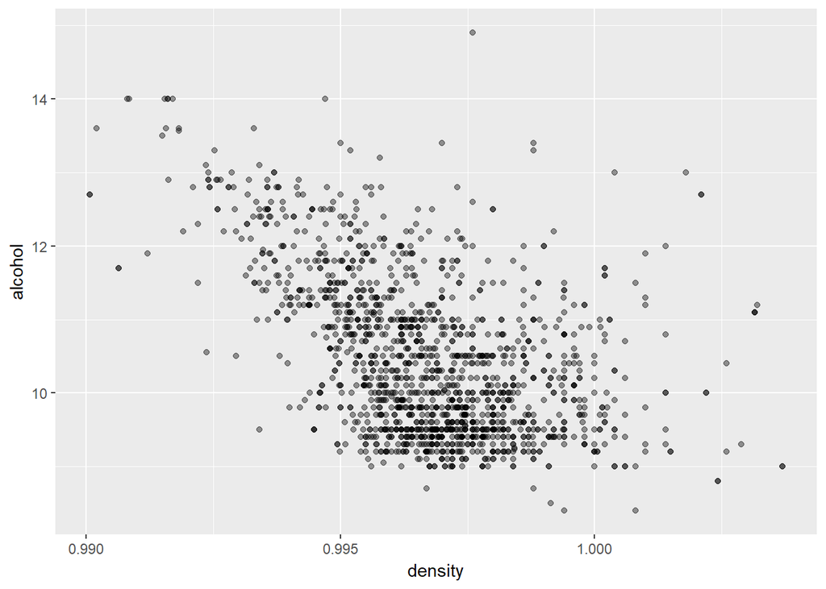

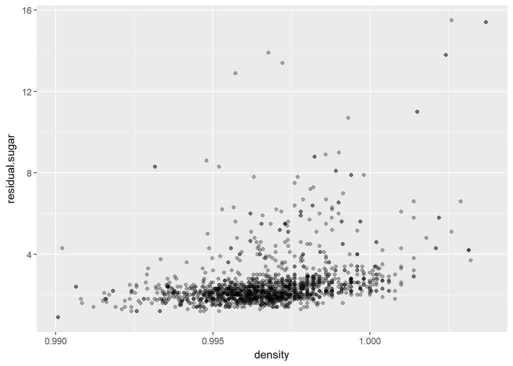

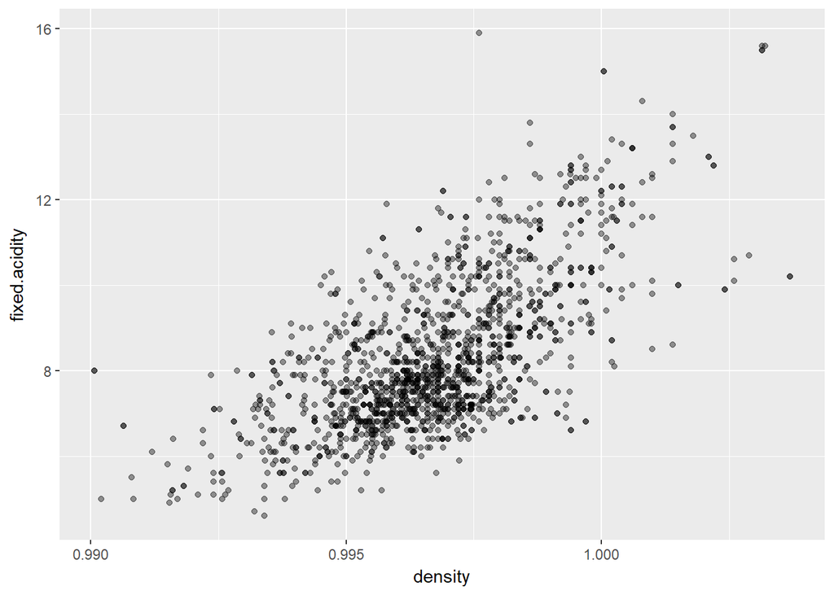

Density has the strongest correlation with fixed acidity, having a pretty clear positive relationship. But I don’t think density has a directly relationship to fixed acidity.

I want to explore fixed acidity a bit more and see how it relates to other variables in the dataset.

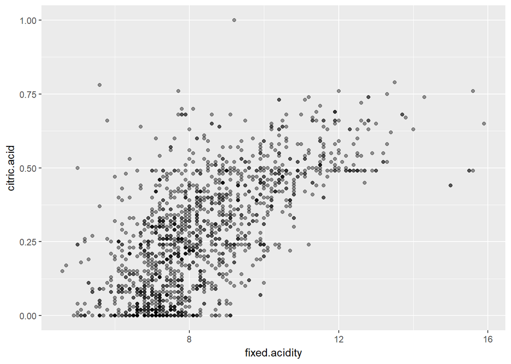

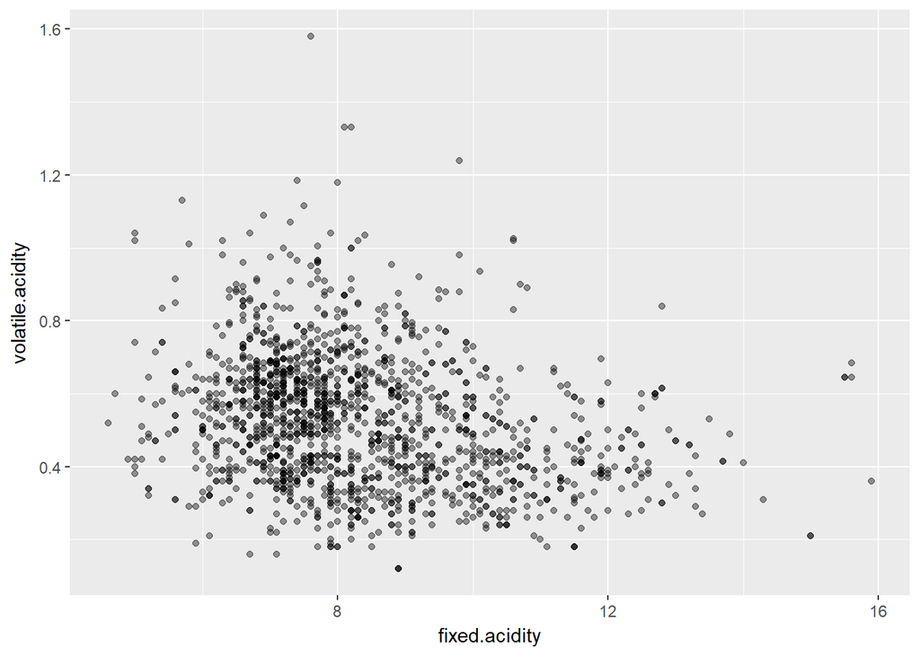

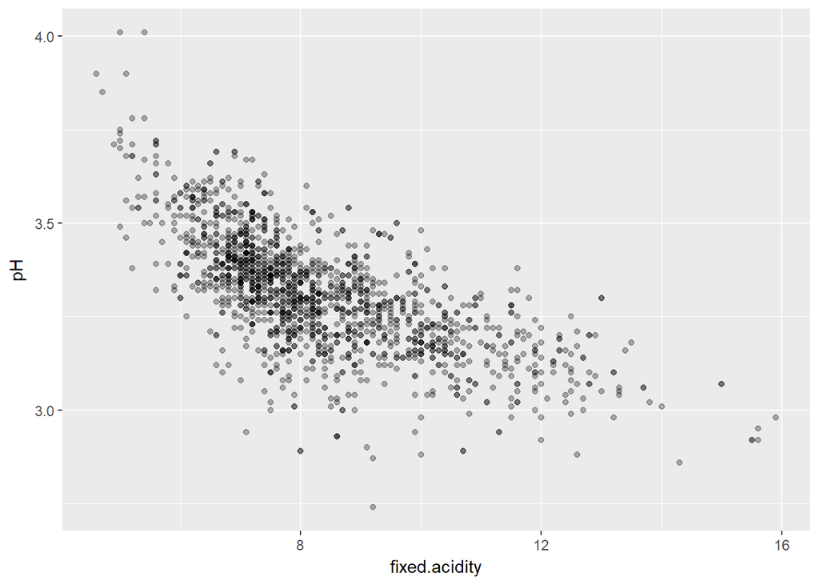

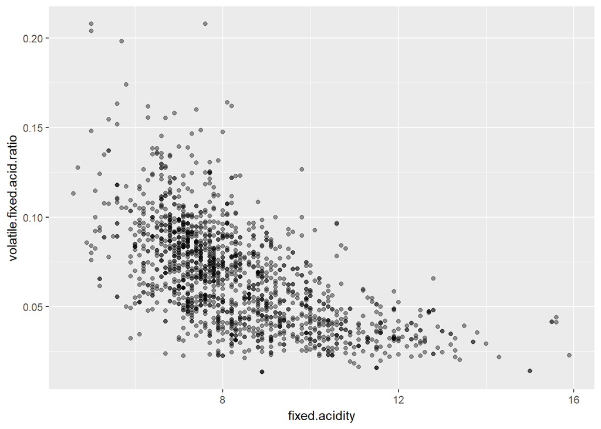

Fixed acidity has a pretty clear positive relationship with citric acid. The relationship seems to be linear but could also be some kind of square root or exponential curve.

Fixed acidity and volatile acidity seem to have a weak negative relationship.

Fixed acidity and pH level has a pretty clear negative relationship as well that seems linear but could also be exponential. Since pH level is determined by acidity this relationship makes sense.

Fixed acidity also has a strong negative relationship with volatile acid ratio. So as fixed acidity goes up, the percentage of volatile acidity typically decreases.

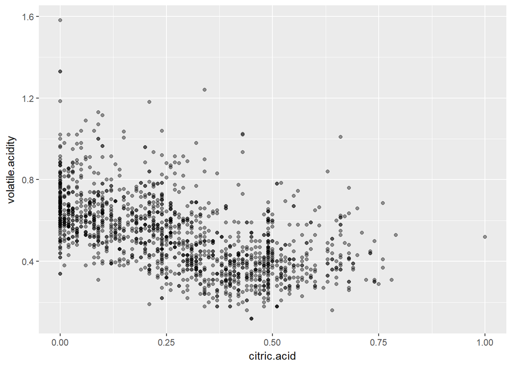

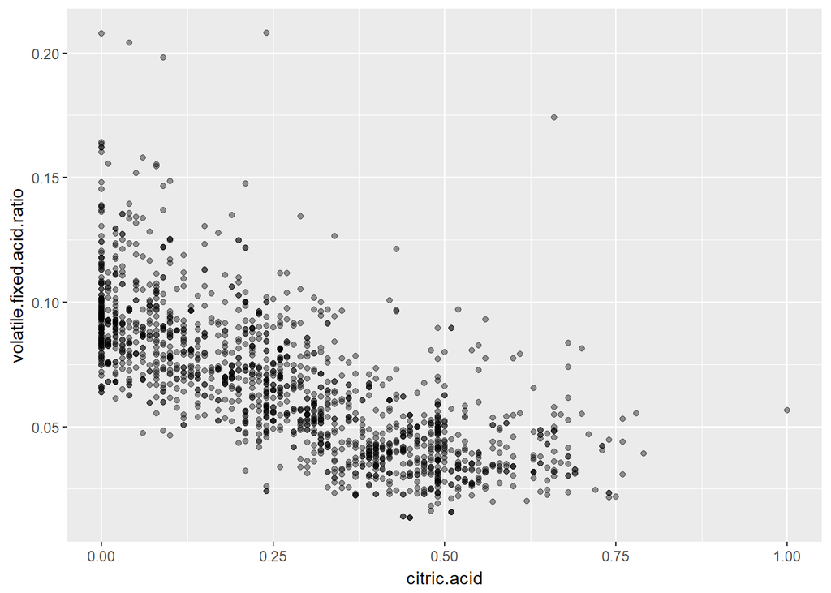

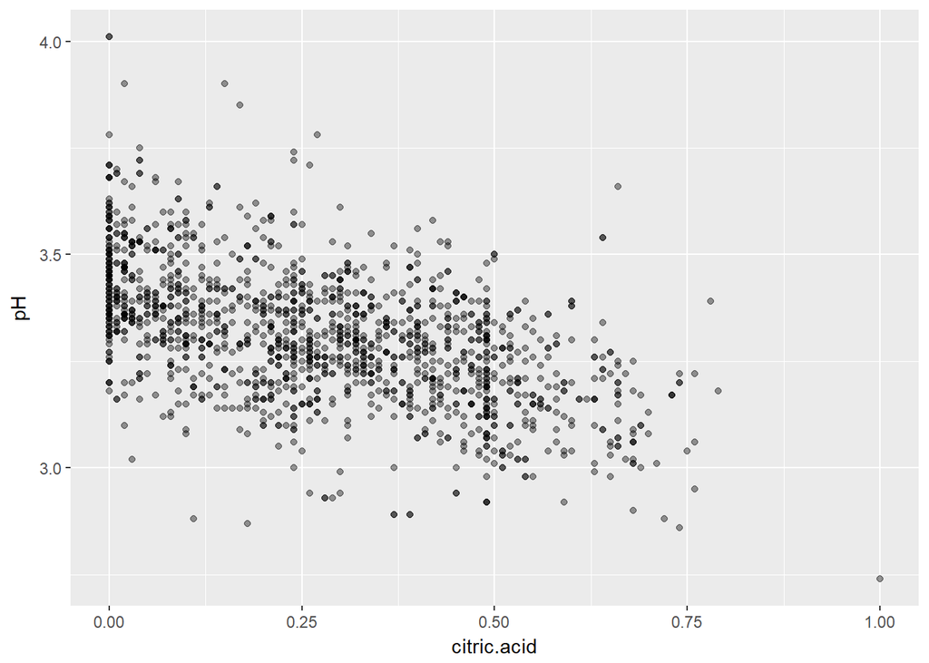

It’s interesting to see that citric acid and volatile acidity have a negative relationship since citric acid and fixed acidity had a distinct positive relationship. I suppose this can make sense since fixed acidity and volatile acidity doesn’t seem to have a strong correlation with each other in the first place. This negative relationship can be seen more easily when plotting the volatile acidity ratio against citric acid.

Citric acid and pH level have a negative relationship as well. This makes sense.

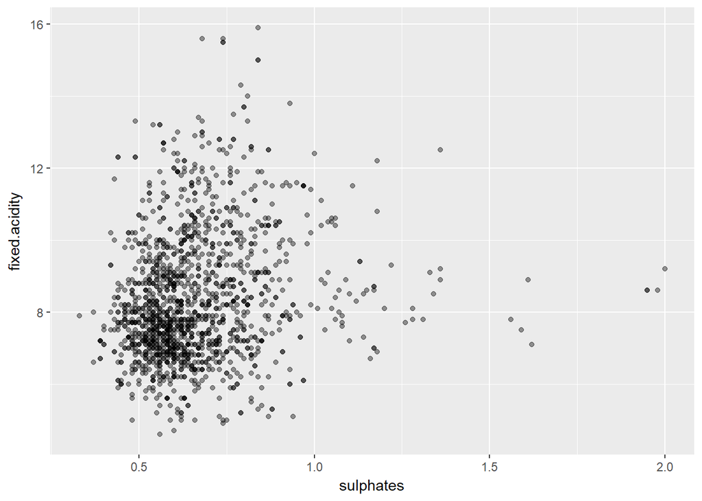

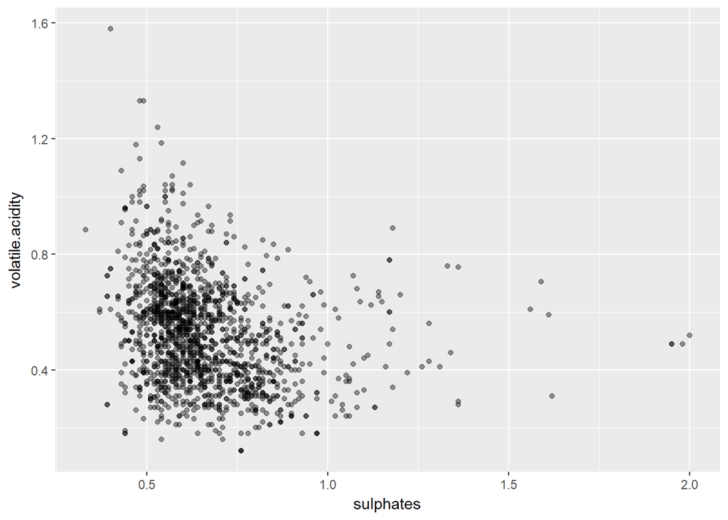

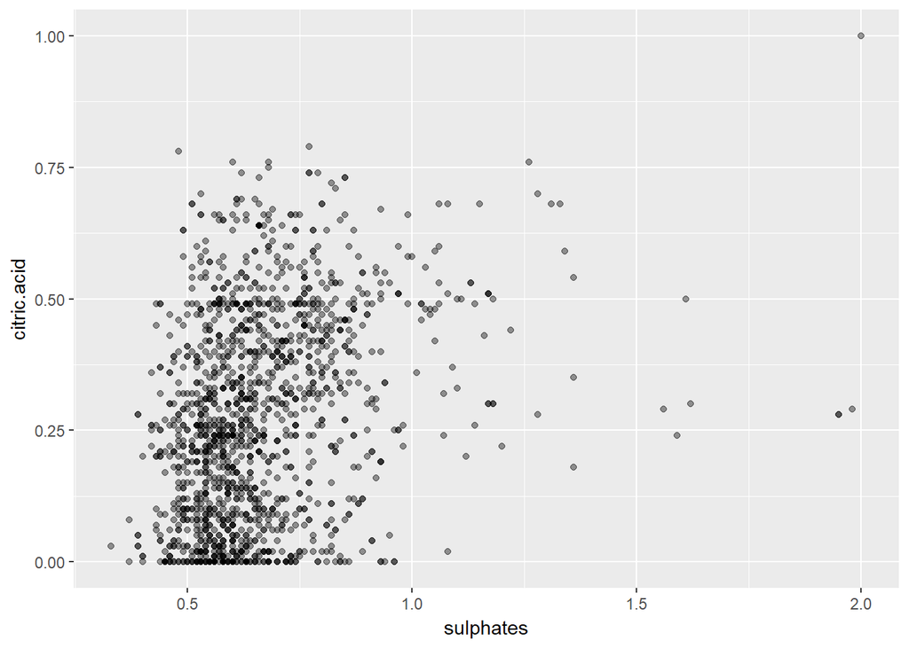

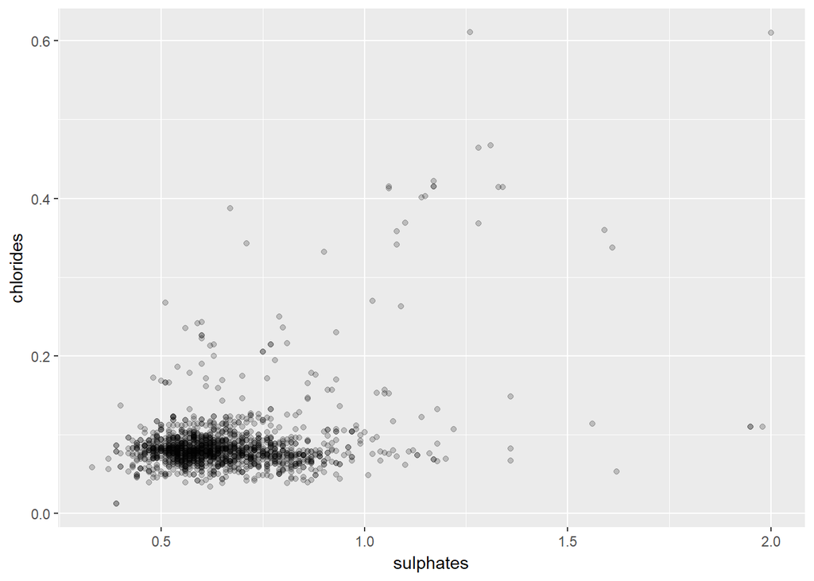

```
##    Min. 1st Qu.  Median    Mean 3rd Qu.    Max.
##  0.3300  0.5500  0.6200  0.6581  0.7300  2.0000
```

Sulphates seems to have a weak negative relationship with volatile acidity.

With citric acid, sulphates seems to have a pretty ambiguous relationship based on the plot above. There is a .313 correlation between those two variables which is relatively strong for this dataset; there isn’t a single variable that has a correlation about .8 in this whole dataset.

Most of the points in these plots are between .5 g/dm^3 and 1 g/dm^3. I looked at the summary of sulphates and it agrees with my observation.

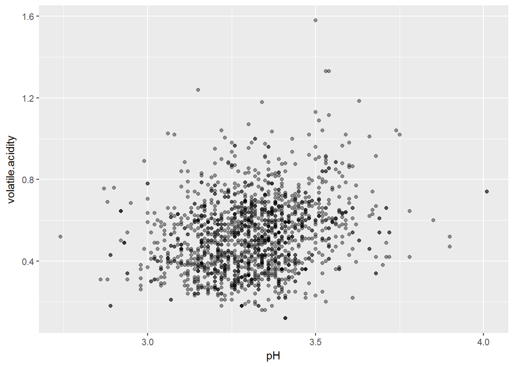

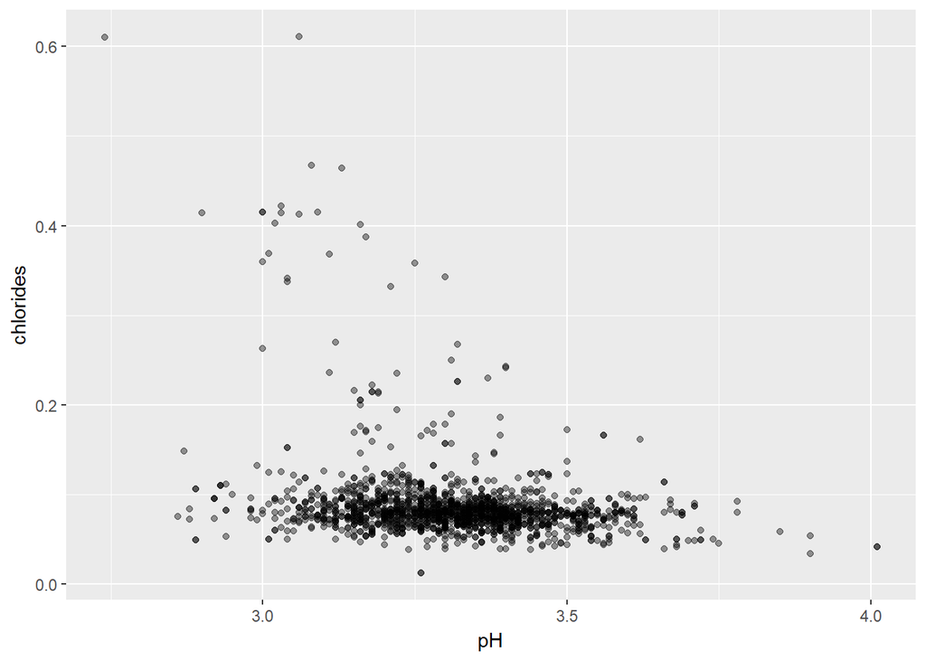

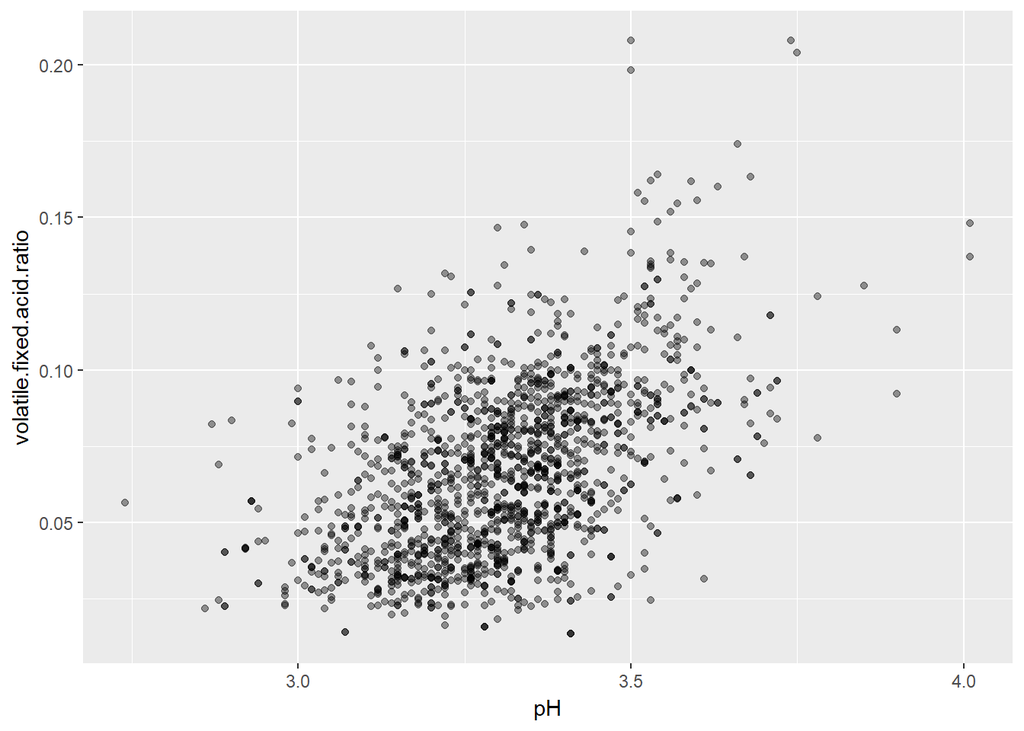

Oddly enough, pH value and volatile acidity doesn’t seem to have a strong relationship at all, if any, based on this plot. This is unusual since there was such a strong negative relationship between pH and fixed acidity. I suppose this makes sense since fixed and volatile acidity didn’t have a strong relationship between themselves either. It seems that citric acid and fixed acidity are more important than volatile acidity when determining pH levels.

pH and chlorides create an odd scatterplot. Most of the values are uniformily at the bottom while a small group seems to create a downward trend. It would be interesting to look at this more later.

pH plotted against volatile acidity ratio has a stronger trend than plotting just volatile acidity. This can be due to the fact that fixed acidity has such a strong relationship with pH and volatile acidity ratio takes into account fixed acidity.

### Bivariate Analysis

##### Talk about some of the relationships you observed in this part of the investigation. How did the feature(s) of interest vary with other features in the dataset?

I found many interesting relationships between the 11 variables in the dataset plotted against quality in the form of boxplots. There are many clear trends. In terms of upward trends, citric acid, sulphates and alcohol stood out the most. In terms of downward trends, volatile acidity, density, and pH stood out the most.

Free and total sulfur dioxide had an upward then downward trend, similar to what a normal distribution looks like. I also noted that it is important to keep in mind the fact that when looking at boxplots with the x variable as quality, to take into account the fact that the data is heavily consisted of quality 5, 6, and 7 red wines. Quality 3, 4, and 8 have very low representation in this dataset. Trying to find trends that span from quality 3 to quality 8 might be misleading. This may or may not explain free and total sulfur dioxide’s upward then downward trend.

##### Did you observe any interesting relationships between the other features (not the main feature(s) of interest)?

In this dataset, some of the variables have relationships between each other that is important to take into account. The most important ones are:

-Alcohol and density have an inverse relationship -As acidity increases, pH level decreases. -The relationship between volatile acidity and fixed acidity is weak -Free sulfur dioxide and total sulfur dioxide has a strong relationship

The reason I think it’s important to take pay attention to the relationship between variables is because based on the boxplots there might be correlations that have ‘lurking’ variables. After seeing the clear trends between pH level and density with wine quality, I began to suspect this. If you only look at the boxplots it might seem that pH and density are direct indicators of quality; however, neither of those are easily recognizable by human senses.

After making some scatterplots of density and pH level with some of the other variables, my hypothesis was strengthened. It is easy to see that density has a strong negative relationship with alcohol. It was also interesting to find that density has a strong relationship positive relationship with fixed acidity. This relationship I can’t explain yet.

I also made some scatterplots of different acidity variables with pH level. I saw clear negative relationships between fixed acidity and pH level and also citric acid and pH level. I was extremely surprised when I plotted pH level and volatile acidity. I thought it would follow the same trends as the previous two variables but the scatterplot shows an almost indistinguishable, non-existent relationship between those two variables. After calculating correlations, I found that pH and volatile acidity had a weak positive relationship of .235.

##### What was the strongest relationship you found?

The strongest relationship I found was fixed acidity and pH level with a correlation of .683.

Some of the variables I created have stronger relationships but I didn’t count that. Volatile acidity has a .897 correlation with volatile acidity ratio. They were too similar since volatile acidity ratio was created by dividing volatile acidity by fixed acidity.

### Multivariate Plots Section

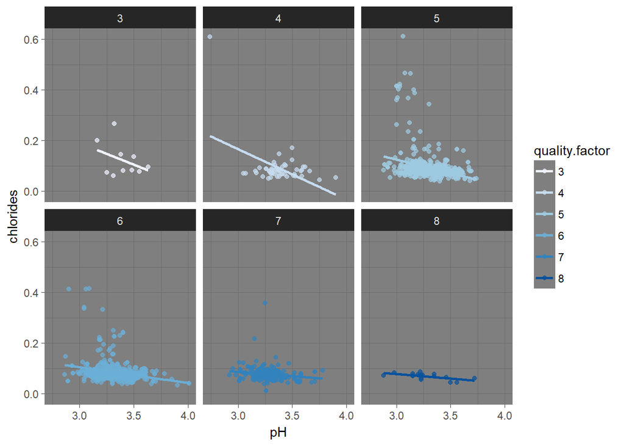

This is a scatterplot comparing pH level with chlorides facetted by quality. It looked strange when I was looking at this plot in my bivariable analysis and wanted to explore it just out of curiousity. I thought there might be more easily distinguishable trends if I facetted the scatterplot by quality but it still doesn’t seem to have any evident trends.

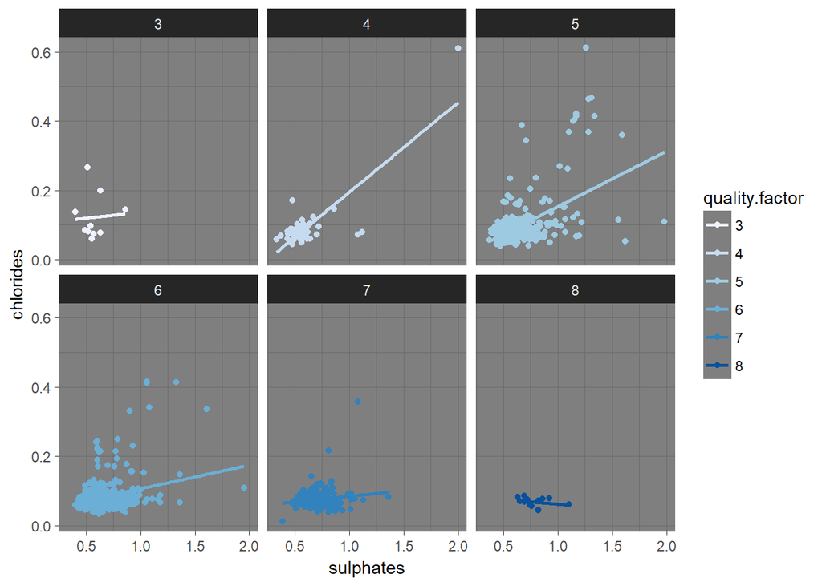

I wanted to make this facetted plot just for exploration as well. I wanted to find out where the scattered points came from. This plot doesn’t quite explain it since every plot has similar features except 3, 4, and 8. There just aren’t enough points in those plots to make any conclusions.

I want to explore some of the variables I created, with quality.

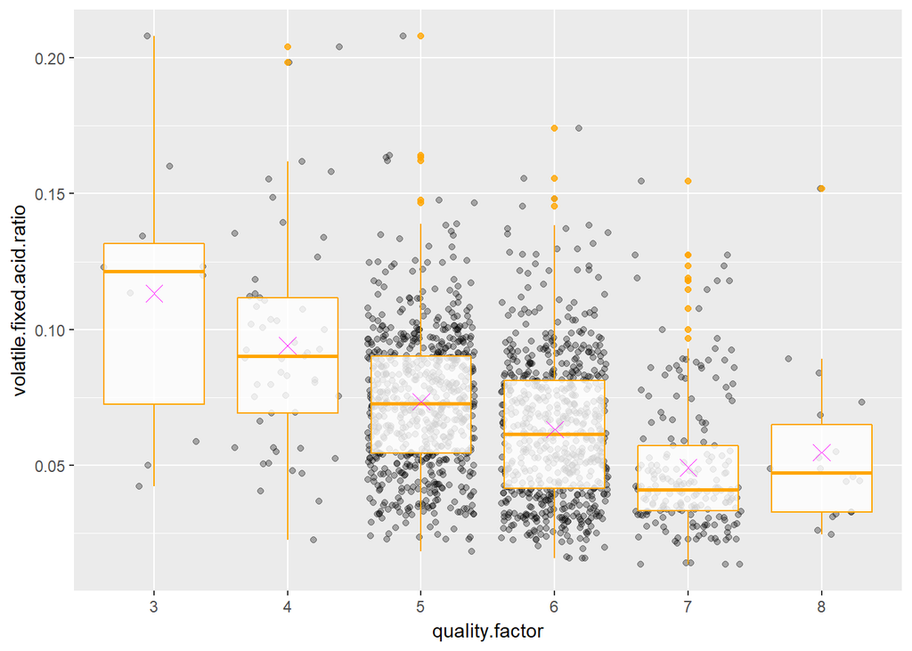

The volatile to fixed acidity ratio seems to follow a similar trend to that of the volatile acidity plot. As the percent of volatile acid goes down, the quality increases. This gives me stronger evidence of the significance of volatile acidity in determining quality of red wine.

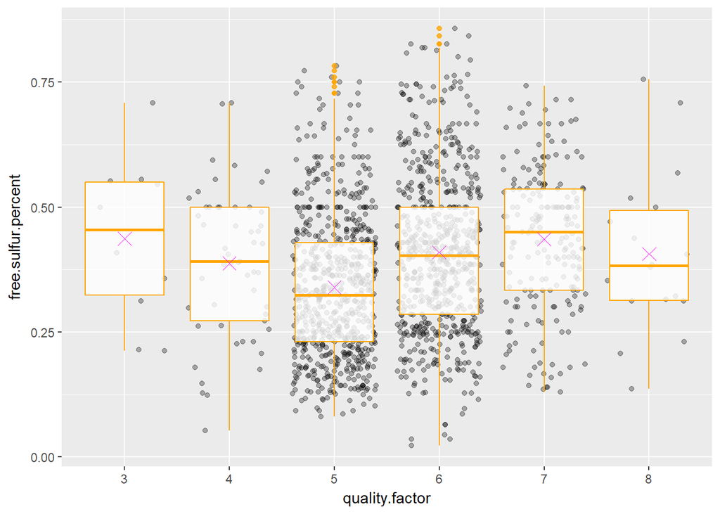

The plot seems to follow a sin curve, however, that doesn’t really make sense in this context. This could be due to the above reason I mentioned about little data coming from the lower and upper qualities. Discounting qualities 3, 4, and 8, you can see a clear upward trend in this data.

It’s also interesting to note that absolute levels of free and total sulfur seem to decrease as quality goes up from 5 to 7, while percentage of free sulfur seems to go up as quality goes up from 5 to 7. So as quality increases, total sulfur dioxide and free sulfur dioxide both decrease; however, the percentage of free sulfur dioxide increases. So higher free sulfur dioxide percentage seems to be a good thing, but overall, sulfur dioxide in general seems to decrease the quality of wine.

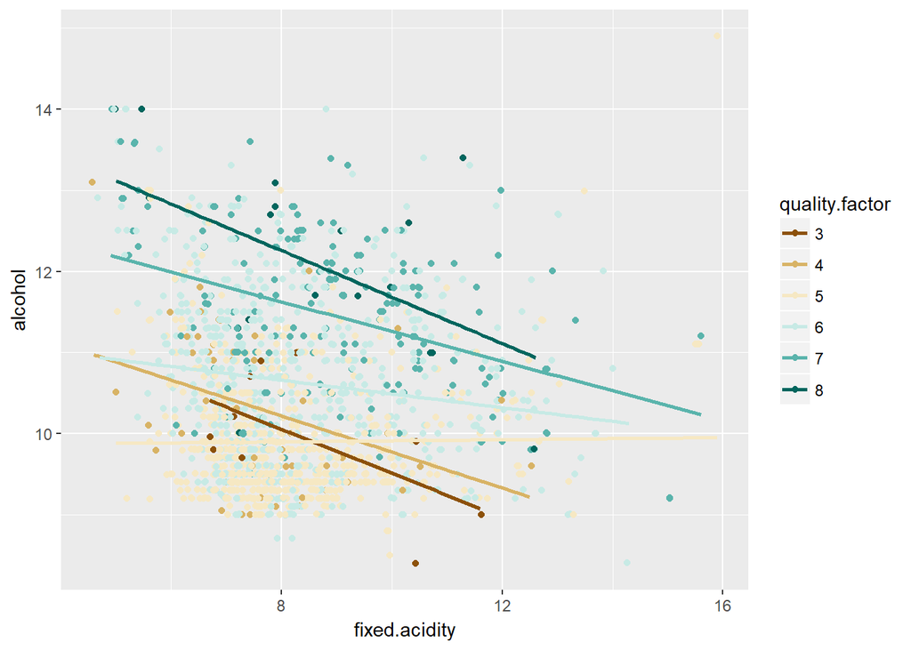

I wanted to add color by quality as a factor variable just to support some of the trends I found in the bivariable analysis. You can see a pretty clear gradient in this plot suggesting that alcohol does indeed influence quality. This gradient is further enhanced by the trend lines.

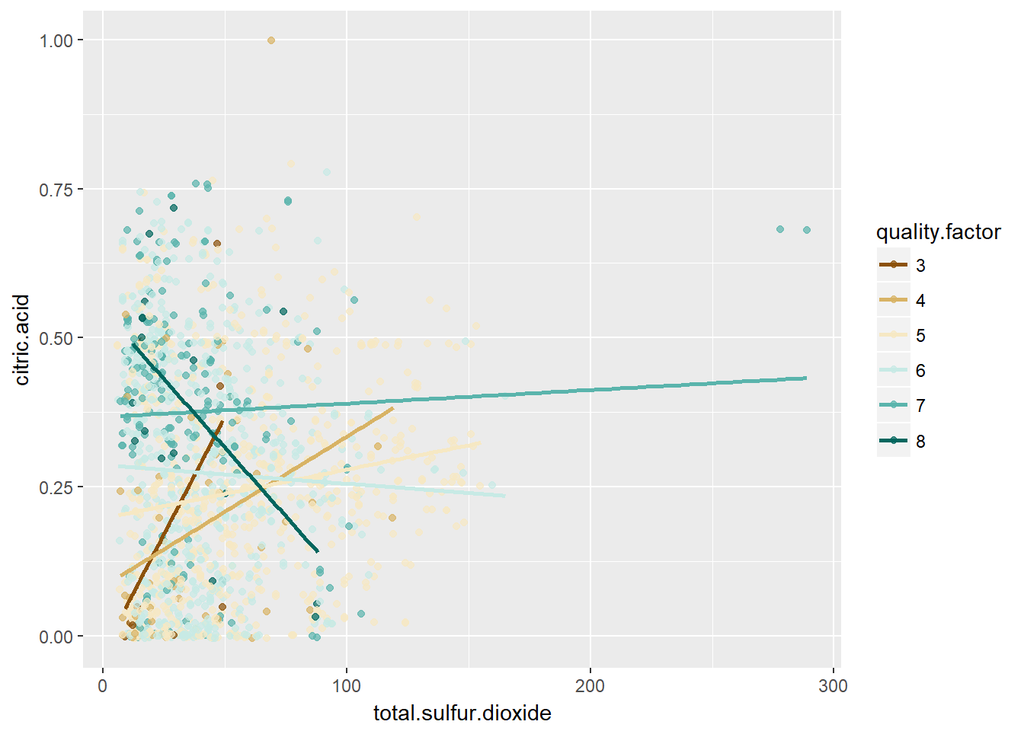

Citric acid seems to have less of a gradient than the alcohol plot. You can see some gradient in the y axis. Despite having a positive relationship with quality, based on this plot it is a weak positive relationship. Interestingly, for quality 3 and 4, the trend lines seem to indicate strong positive relationships that slowly become negative as quality increases.

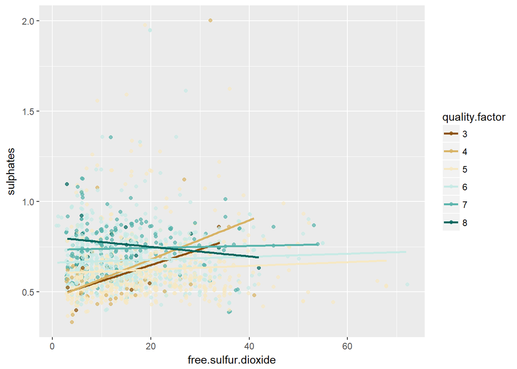

There is also an upward gradient in this plot; as sulphates increase, quality seems to increase as well. Here the relationship seems to start at positive and slowly go towards a negative trend as quality increases similar to the previous graph.

I want to confirm some of the negative trends that I noticed in my bivariable analysis.

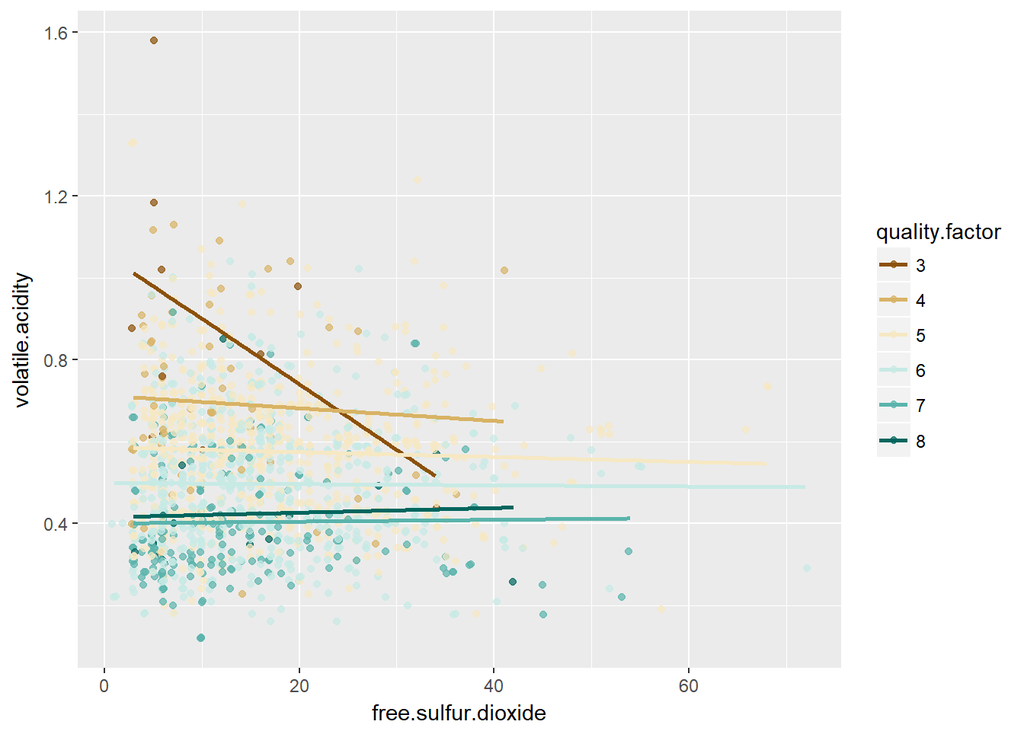

There is a pretty clear downward trend in the above plot. This helps me confirm the relationship between volatile acidity and quality further.

```
##
## Calls:
## m1: lm(formula = quality ~ alcohol, data = redwine)
## m2: lm(formula = quality ~ alcohol + volatile.acidity, data = redwine)
## m3: lm(formula = quality ~ alcohol + volatile.acidity + citric.acid,
##     data = redwine)
## m4: lm(formula = quality ~ alcohol + volatile.acidity + citric.acid +
##     sulphates, data = redwine)
##
## ================================================================
##                        m1         m2         m3         m4
## ----------------------------------------------------------------
##   (Intercept)        1.875***   3.095***   3.055***   2.646***
##                     (0.175)    (0.184)    (0.194)    (0.201)
##   alcohol            0.361***   0.314***   0.314***   0.309***
##                     (0.017)    (0.016)    (0.016)    (0.016)
##   volatile.acidity             -1.384***  -1.343***  -1.265***
##                                (0.095)    (0.114)    (0.113)
##   citric.acid                              0.068     -0.079
##                                           (0.103)    (0.104)
##   sulphates                                           0.696***
##                                                      (0.103)
## ----------------------------------------------------------------
##   R-squared             0.227      0.317      0.317      0.336
##   adj. R-squared        0.226      0.316      0.316      0.334
##   sigma                 0.710      0.668      0.668      0.659
##   F                   468.267    370.379    246.976    201.777
##   p                     0.000      0.000      0.000      0.000
##   Log-likelihood    -1721.057  -1621.814  -1621.596  -1599.093
##   Deviance            805.870    711.796    711.603    691.852
##   AIC                3448.114   3251.628   3253.192   3210.186
##   BIC                3464.245   3273.136   3280.078   3242.448
##   N                  1599       1599       1599       1599
## ================================================================
```

```
##
## Call:
## lm(formula = quality ~ fixed.acidity + volatile.acidity + citric.acid +
##     residual.sugar + chlorides + free.sulfur.dioxide + total.sulfur.dioxide +
##     density + pH + sulphates + alcohol + free.sulfur.percent +
##     volatile.fixed.acid.ratio, data = redwine)
##
## Residuals:
##      Min       1Q   Median       3Q      Max
## -2.73553 -0.36180 -0.05121  0.44665  2.13691
##
## Coefficients:
##                             Estimate Std. Error t value Pr(>|t|)
## (Intercept)                2.367e+01  2.218e+01   1.067    0.286
## fixed.acidity              5.805e-03  2.884e-02   0.201    0.841
## volatile.acidity          -5.460e-01  4.167e-01  -1.310    0.190
## citric.acid               -1.776e-01  1.471e-01  -1.207    0.228
## residual.sugar             1.854e-02  1.515e-02   1.224    0.221
## chlorides                 -1.825e+00  4.199e-01  -4.346 1.48e-05 ***
## free.sulfur.dioxide       -7.114e-04  3.920e-03  -0.181    0.856
## total.sulfur.dioxide      -1.673e-03  1.282e-03  -1.305    0.192
## density                   -1.987e+01  2.263e+01  -0.878    0.380
## pH                        -3.092e-01  2.053e-01  -1.506    0.132
## sulphates                  9.261e-01  1.152e-01   8.039 1.75e-15 ***
## alcohol                    2.726e-01  2.658e-02  10.256  < 2e-16 ***
## free.sulfur.percent        3.302e-01  2.168e-01   1.523    0.128
## volatile.fixed.acid.ratio -4.290e+00  3.119e+00  -1.376    0.169
## ---
## Signif. codes:  0 '***' 0.001 '**' 0.01 '*' 0.05 '.' 0.1 ' ' 1
##
## Residual standard error: 0.6476 on 1585 degrees of freedom
## Multiple R-squared:  0.3623, Adjusted R-squared:  0.357
## F-statistic: 69.26 on 13 and 1585 DF,  p-value: < 2.2e-16
```

The model that I built doesn’t seem to be a great predictor of wine quality. I’m honestly not surprised by this since based on the correlation matrix there weren’t very many strong relationships over +/- .7 anyway. I wanted to make sure I didn’t make a complete mistake so I made a model using all the variables in the dataset. Looking at the r^2 values in both my model and a model using all the variables, it’s clear to see that my model isn’t too far off.

### Multivariate Analysis

##### Talk about some of the relationships you observed in this part of the investigation. Were there features that strengthened each other in terms of looking at your feature(s) of interest?

The boxplot of volatile acidity ratio with quality helped strengthen my hypothesis that volatile acidity played a part in quality. Quality seems to increase as the percentage of volatile acidity to fixed acidity decreases. I also made scatterplots of alcohol, volatile acidity, citric acid, and sulphates ordered by quality to see if there was any observed gradients which might strengthen my hypthoesis that those variables play a part in determining quality; and they all did have gradients to differing degrees. I plotted those variables against variables that I knew they had little correlation with so it would be easier to see the gradients. If I used an x variable that was highly correlated with the y variable the gradient may be harder to see.

##### Were there any interesting or surprising interactions between features?

I made a boxplot of the percentage of free sulfur dioxide to total sulfur dioxide against quality and the plot looked strange. As I mentioned about, the trend almost follows a sine curve going down and up. It also seems to be the reverse of the free sulfur dioxide and total sulfur dioxide boxplots since both of those have a trend going up then down.

##### Did you create any models with your dataset? Discuss the strengths and limitations of your model.

I created a model to predict quality with inputs that I believed were significant determinate factors based on the plots that I made in my analysis. However, I was quite surprised at first when I saw that the r^2 value was so low at less than .4. This means that my model did a poor job of predicting quality. I then made another model where I used every single variable in the dataset except X to see how that model compared to mine. It turns out that a model using every input variable still did a really poor job of predicting quality, only having an r^2 of approximately .02 higher than my model. This made more sense after I looked at the correlation matrix and saw that most correlations between any of the variables as well as the output was lower than .7.

Also, quality was a subjective output based on human taste. I don’t think that physicochemical inputs are good predictors of a subjective human output especially in something that humans have to taste. Taste isn’t one of human’s strongest senses and studies show that humans can only distinguish about 1.9 bits or 4 distinct taste concentrations when tested with salt. I’m sure wine is more complex than just straight NaCl but I believe these human limitations still must exist to some extent when it comes to red wine as well. Maybe inputs like grape type, wine brand, and other non-physicochemical inputs would make this model more robust.

### Final Plots and Summary

##### Plot One

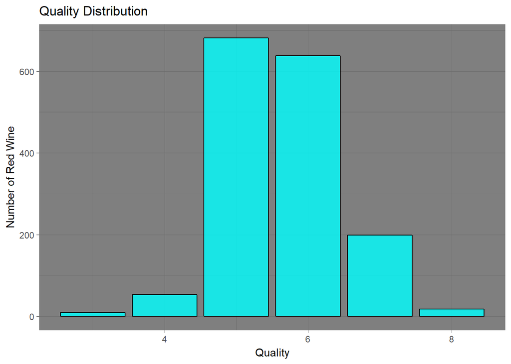

##### Description

I think that this plot is one of the most important in my univariable analysis because it highlights the number of wines of each quality. It’s evident that most of the wine are of quality 5, 6, and 7. With so little data in quality 3, 4, and 8, it is hard to be certain of trends that may exist when looking at quality in a linear fashion.

##### Plot Two

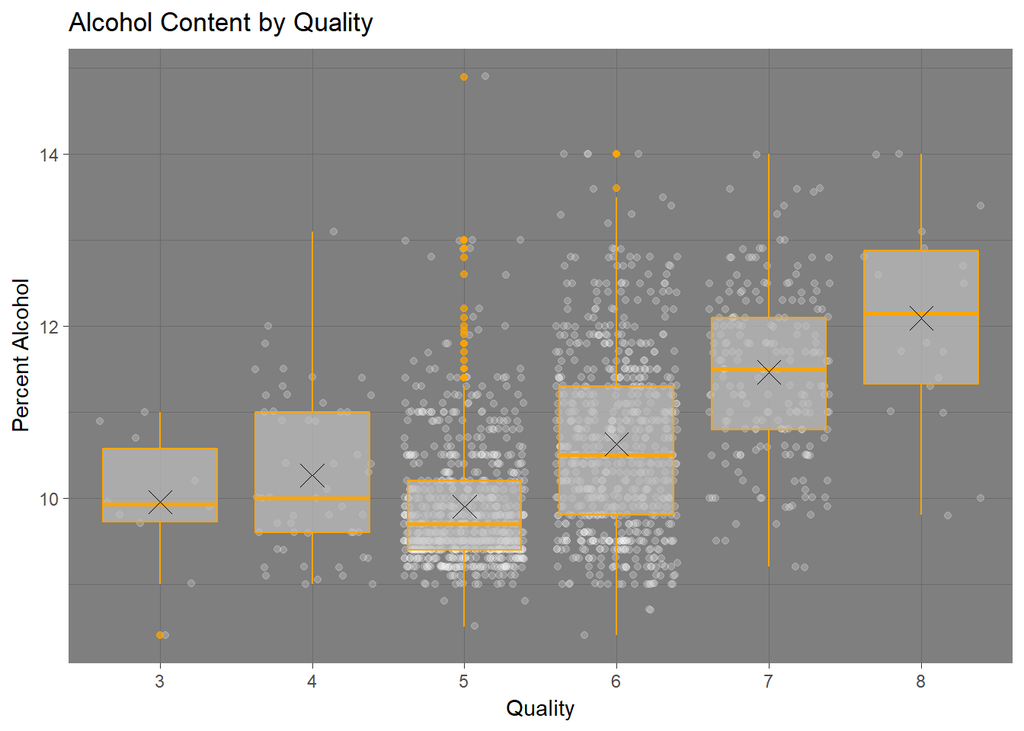

##### Description

This plot is interesting because it shows how strong of a relationship alcohol content plays in the quality of red wine. I initially thought alcohol is just a static factor in red wine since all wine has alcohol anyway. It turns out that stronger wine seem to be of better quality. Curious how this trend would look if alcohol content went up to 20 or 30 or more.

##### Plot Three

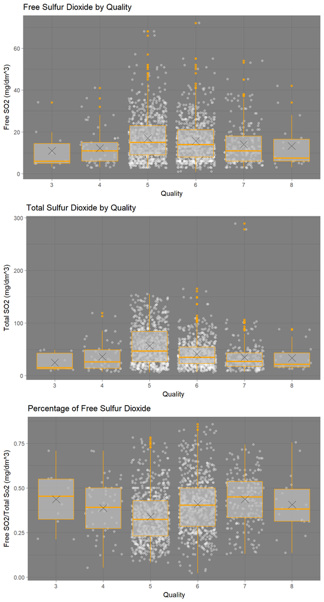

##### Description

I thought that this series of plots was really quite interesting. When I plotted free sulfur dioxide and total sulfur dioxide against quality, both had really similar trends going up until quality 5 then back down. However, when I plotted free sulfur dioxide/total sulfur dioxide the trend looked almost like a sine wave and was almost the opposite trend going down to quality 5 then back up and dips down a little again at quality 8. I thought it was interesting that the percentage of free sulfur dioxide is decreasing when the absolute number of sulfur and total sulfur are increasing and when the percentage of free sulfur increases, the absolute number of free and total sulfur is decreasing.

### Reflection

The red wine dataset contains information on almost 1,600 red wines across 12 variables around 2009. I started by exploring the individual variables in the data set and continued to explore the data in more complex ways as interesting observations and questions came to mind. Eventually, I explored the quality of red wine across many variables and created a linear model to predict red wine quality.

The entired dataset consisted of mainly quality 5, 6, and 7 wines and in total ranged from quality 3 to 8 wines. After noting the small quantity of data in wines of quality 3, 4, and 8, I began to look at trends all the variables in the datatset to understand relationships between all vraibles since I knew little about red wine. I noticed immmediately that there was such low correlation between all the variables with each other and with quality. There was almost no two variables whose correlation was greater than the absolute value of .7. This led me to believe starting off that physicochemical variables were potentially bad predictors of quality in wine since the output is a subjective categorization of the wine. This categorization was based of human taste and judgement rather than based off any objective mathematical formula. I started by changing quality from a numeric variable to a factor variable so it would be easier to analyze in boxplots. I did observe some clear upward trends between quality and citric acid, alcohol, and suphates and downward trends between quality and volatile acidity, pH and, density. Surprisingly, free sulfur dioxide and total sulfur dioxide didn’t seem to have a strong relationship with quality despite the fact that it did present one of the most interesting plots in my analysis. Along with creating my quality factor variable I also created two variables for free sulfur dioxide/total sulfur dioxide as well as volatile acidity/fixed acidity just to see if I could find any interesting trends there. After creating a linear model to predict quality based on alcohol, volatile acidity, citric acid, and sulphates, I was surprised at first to discover that my model only accounted for about 33.6% of the variance in the dataset! However, I thought back and realized most of the relationships between the variables were weak in the first place. Making me think that physicochemical variables may not be the best predictor of wine quality. I created a linear model based on all the variables in the dataset except X which is just the count, and was pleasantly surprised to find that with all the variables included, the model still only accounted for about 2% more of the variance in the dataset than my model.

Limitations: Coming in to this analysis, I knew that human’s sense of taste was the weakest of all their senses based on a Harvard paper by George Miller (1956). In the paper he states that when testing humans on their absolute judgement of unidimensional stimuli for taste, that the channel capacity is 1.9 bits, which means humans can discern about 4 distinct concentrations when tested with salt (NaCl). I know that red wine is more complex than just pure salt, however, having a quality output based on human’s weakest sense is bound to be hard to predict using objective numerical variables as inputs. Making humans choose a number between 1 and 10 to categorize the ‘quality’ of red wine, I assume is quite difficult. It would be interesting to have some non-physicochemical data on the kind of grapes, year of production, wine brand and such. Maybe having some historical data as well on wine quality could help make this model more robust as well.